# Getting Started with pgscatalogcolors

Brooke N. Wolford (ORCID: 0000-0003-3153-1552)

pgscatalogcolors 0.1.0 — 2026-05-07

```r
library(pgscatalogcolors)
library(ggplot2)
```

## What ancestry acronyms are available?

The package maps **19 ancestry categories** defined by the [PGS Catalog ancestry documentation](https://www.pgscatalog.org/docs/ancestry/). Call `pgscatalog_ancestry_info()` to see the full lookup table:

```r
pgscatalog_ancestry_info()
```

```
#>    acronym                           ancestry pop_group   color
#> 1      ABO              Aboriginal Australian       DIV #999999
#> 2      AAM African American or Afro-Caribbean       AFR #F9DA49
#> 3      AFR                African unspecified       AFR #F9DA49
#> 4      ASN                  Asian unspecified       ASN #B25928
#> 5      CAS                      Central Asian       ASN #B25928
#> 6      EAS                         East Asian       EAS #68AD57
#> 7      EUR                           European       EUR #377EB8
#> 8      MID             Greater Middle Eastern       MID #5DCBCF
#> 9      HIS         Hispanic or Latin American       HIS #D1352B
#> 10     AMR                    Native American       DIV #999999
#> 11     NON                       Not Reported       NON #BBBBBB
#> 12     OCE                           Oceanian       DIV #999999
#> 13     OTH                              Other       DIV #999999
#> 14     ADA             Other admixed ancestry       DIV #999999
#> 15     SAS                        South Asian       SAS #984EA4
#> 16     SEA                   South East Asian       ASN #B25928
#> 17     SAF                Sub-Saharan African       AFR #F9DA49
#> 18     MIE Multi-Ancestry including Europeans       MIE #E887BD
#> 19     MEE Multi-Ancestry excluding Europeans       MEE #EF8632
```

The columns are:

| Column | Description |
| --- | --- |
| `acronym` | The string the scale functions match against (exact, case-sensitive; use `pgscatalog_match()` to normalise messy labels) |
| `ancestry` | Full PGS Catalog ancestry label |
| `pop_group` | Broader population group abbreviation (1000G/HGDP-style) |
| `color` | Hex color assigned to that acronym |

## What does my data frame need?

Your data frame needs **one column whose values are ancestry acronyms**. The scale functions match these exactly and case-sensitively against the `acronym` column above. The column can have any name; you point ggplot2 to it with `aes(color = <your_column>)`.

If your labels are messy — typos, inconsistent capitalisation, full names, or underscores as separators — use `pgscatalog_match()` to clean them up first (see What if my labels have typos or inconsistent formatting? below).

```r
# Minimal working example
df <- data.frame(
  sample_id  = paste0("s", 1:6),
  pgs_score  = c(0.42, -0.11, 0.87, 0.03, -0.55, 0.29),
  ancestry   = c("EUR", "AFR", "EAS", "SAS", "HIS", "MID")
  #              ^-- must match acronyms exactly
)
df
```

```
#>   sample_id pgs_score ancestry
#> 1        s1      0.42      EUR
#> 2        s2     -0.11      AFR
#> 3        s3      0.87      EAS
#> 4        s4      0.03      SAS
#> 5        s5     -0.55      HIS
#> 6        s6      0.29      MID
```

The `ancestry` column values must be **character or factor** — numeric codes will not match. The column does **not** need to contain all 19 acronyms; only the ones present in your data are plotted.

## PGS odds ratio forest plot

A common use case is plotting the odds ratio (OR) of a polygenic score across ancestry groups, with ancestry on the y-axis and the OR on the x-axis. Each point is coloured by ancestry using the PGS Catalog palette.

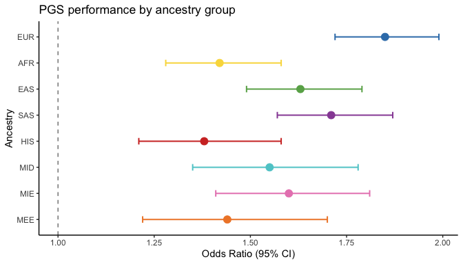

```r
set.seed(42)
groups <- c("EUR", "AFR", "EAS", "SAS", "HIS", "MID", "MIE", "MEE")

forest_df <- data.frame(
  ancestry = factor(groups, levels = rev(groups)),
  OR       = c(1.85, 1.42, 1.63, 1.71, 1.38, 1.55, 1.60, 1.44),
  lower    = c(1.72, 1.28, 1.49, 1.57, 1.21, 1.35, 1.41, 1.22),
  upper    = c(1.99, 1.58, 1.79, 1.87, 1.58, 1.78, 1.81, 1.70)
)

ggplot(forest_df, aes(x = OR, y = ancestry, color = ancestry)) +
  geom_vline(xintercept = 1, linetype = "dashed", colour = "grey50") +
  geom_errorbarh(aes(xmin = lower, xmax = upper), height = 0.25, linewidth = 0.7) +
  geom_point(size = 3.5) +
  scale_color_pgscatalog() +
  scale_x_continuous(breaks = seq(1, 2, 0.25)) +
  labs(
    x     = "Odds Ratio (95% CI)",
    y     = "Ancestry",
    title = "PGS performance by ancestry group"
  ) +
  theme_classic() +
  theme(legend.position = "none")
```

## Basic scatter plot

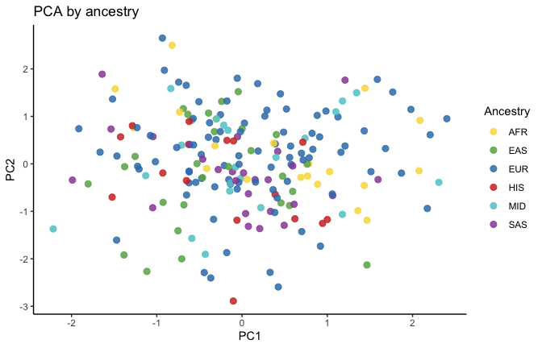

```r
set.seed(1)
n   <- 200
grp <- c("EUR", "AFR", "EAS", "SAS", "HIS", "MID")

df <- data.frame(
  PC1      = rnorm(n),
  PC2      = rnorm(n),
  ancestry = sample(grp, n, replace = TRUE,
                    prob = c(0.40, 0.15, 0.15, 0.12, 0.10, 0.08))
)

ggplot(df, aes(PC1, PC2, color = ancestry)) +
  geom_point(size = 2.5, alpha = 0.85) +
  scale_color_pgscatalog() +
  labs(title = "PCA by ancestry", color = "Ancestry") +
  theme_classic()
```

## Bar chart (fill aesthetic)

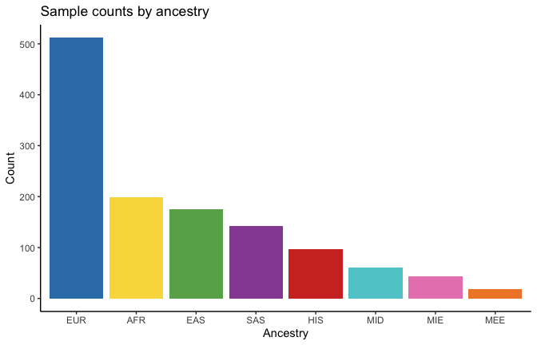

```r
counts <- data.frame(
  ancestry = c("EUR", "AFR", "EAS", "SAS", "HIS", "MID", "MIE", "MEE"),
  n        = c(512, 198, 175, 143, 97, 61, 44, 18)
)

ggplot(counts, aes(reorder(ancestry, -n), n, fill = ancestry)) +
  geom_col() +
  scale_fill_pgscatalog() +
  labs(x = "Ancestry", y = "Count", title = "Sample counts by ancestry") +
  theme_classic() +
  theme(legend.position = "none")
```

## Using `scale_color_manual()` directly

If you need more control (e.g., custom legend labels), use `pgscatalog_scale_values()` to get only the colors for groups in your data:

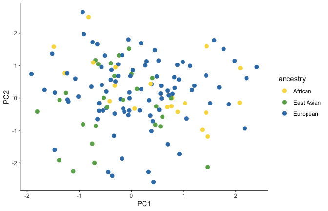

```r
my_groups <- c("EUR", "AFR", "EAS")

ggplot(df[df$ancestry %in% my_groups, ], aes(PC1, PC2, color = ancestry)) +
  geom_point(size = 2.5) +
  scale_color_manual(
    values = pgscatalog_scale_values(my_groups),
    labels = c(AFR = "African", EAS = "East Asian", EUR = "European")
  ) +
  theme_classic()
```

## Checking colors programmatically

```r
# Look up specific colors by acronym
pgscatalog_cols("EUR", "AFR", "EAS")
```

```
#>       EUR       AFR       EAS
#> "#377EB8" "#F9DA49" "#68AD57"
```

```r
# Check whether your acronyms are all recognized before plotting
my_data_groups <- c("EUR", "AFR", "XYZ")   # "XYZ" is not a valid acronym
pgscatalog_scale_values(my_data_groups)     # warns about unknown acronyms
```

[output not shown]

## Cumulative risk curves by PGS quintile

When multiple curves belong to the same ancestry group — for example, PGS quintile-stratified cumulative risk curves — use `pgscatalog_tints()` to generate perceptually ordered color variants derived from that ancestry’s base color. Use `facet_wrap()` to display multiple ancestries side by side, with each panel using that ancestry’s own tint ramp.

```r
# Five EUR tint variants, light to dark
pgscatalog_tints("EUR", n = 5)
```

```
#>         1         2         3         4         5
#> "#B0CCE3" "#70A2CC" "#3579B0" "#2C587C" "#223849"
```

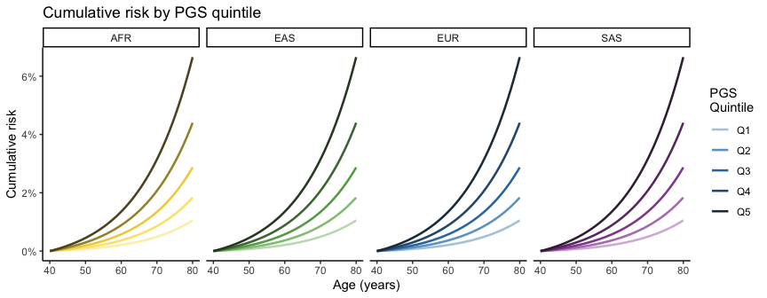

```r
ggplot(df_tints, aes(age, risk, colour = group, group = group)) +
  geom_line(linewidth = 0.9) +
  scale_color_manual(values = line_cols,
                     breaks = paste0("EUR_", quintiles),
                     labels = quintiles, name = "PGS\nQuintile") +
  scale_y_continuous(labels = scales::percent_format(accuracy = 1)) +
  facet_wrap(~ ancestry, nrow = 1) +
  labs(x = "Age (years)", y = "Cumulative risk",
       title = "Cumulative risk by PGS quintile") +
  theme_classic()
```

## Cumulative risk curves with 95% CI ribbons

For plots with per-quintile 95% CI ribbons, build the colour and fill scales manually so both aesthetics share the same tint ramp. Place `geom_ribbon()` *before* `geom_line()` so ribbons sit behind lines.

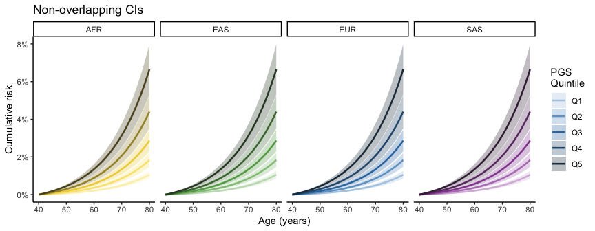

```r
ggplot(df_ci, aes(age, risk, colour = group, fill = group, group = group)) +
  geom_ribbon(aes(ymin = lower, ymax = upper), alpha = 0.3, colour = NA) +
  geom_line(linewidth = 0.9) +
  scale_color_manual(values = line_cols,
                     breaks = paste0("EUR_", quintiles),
                     labels = quintiles, name = "PGS\nQuintile") +
  scale_fill_manual(values  = line_cols,
                    breaks  = paste0("EUR_", quintiles),
                    labels  = quintiles, name = "PGS\nQuintile") +
  scale_y_continuous(labels = scales::percent_format(accuracy = 1)) +
  facet_wrap(~ ancestry, nrow = 1) +
  labs(x = "Age (years)", y = "Cumulative risk",
       title = "Non-overlapping CIs") +
  theme_classic()
```

When CIs overlap heavily, draw the darkest ribbons first by reversing the factor levels on a separate ribbon data frame. This ensures lighter (lower-risk) ribbons are painted on top, preserving readability.

> **When does this approach break down?** Reversing the draw order helps when adjacent bands *partially* overlap — the lighter ribbons remain visible on top. However, if confidence intervals are so wide that they completely engulf one another (e.g., Q1’s band fully covers Q5’s at all ages), no draw order can recover individual bands. In that situation, consider: (1) displaying fewer quintiles, (2) adding direct line labels instead of a ribbon fill, or (3) splitting groups into separate facets so each panel’s CI bands are readable on their own.

> **Number of strata:** `pgscatalog_tints()` issues a warning when `n > 8` (adjacent variants may be hard to distinguish in dense legends) and a stronger warning when `n > 10` (adjacent variants likely to be confused). These warnings fire automatically whenever you call `pgscatalog_tints()` or any of the scale wrappers with a large `n`.

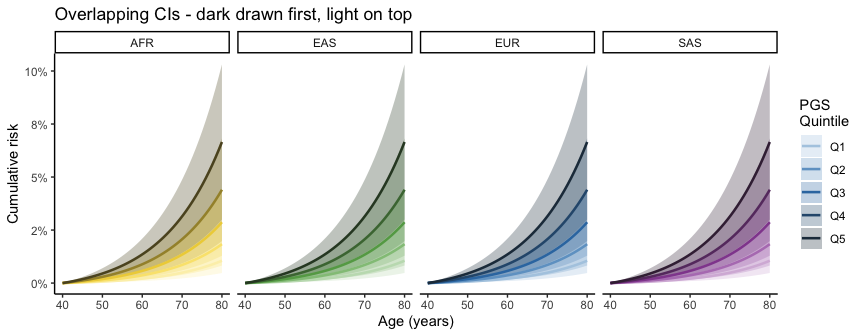

```r
ggplot() +
  geom_ribbon(data = df_rib2,
              aes(x = age, ymin = lower, ymax = upper,
                  fill = group, group = group),
              alpha = 0.3, colour = NA) +
  geom_line(data = df_ci2,
            aes(x = age, y = risk, colour = group, group = group),
            linewidth = 0.9) +
  scale_color_manual(values = line_cols,
                     breaks = paste0("EUR_", quintiles),
                     labels = quintiles, name = "PGS\nQuintile") +
  scale_fill_manual(values  = line_cols,
                    breaks  = paste0("EUR_", quintiles),
                    labels  = quintiles, name = "PGS\nQuintile") +
  scale_y_continuous(labels = scales::percent_format(accuracy = 1)) +
  facet_wrap(~ ancestry, nrow = 1) +
  labs(x = "Age (years)", y = "Cumulative risk",
       title = "Overlapping CIs - dark drawn first, light on top") +
  theme_classic()
```

## Color vision deficiency

The PGS Catalog palette was not originally designed with color vision deficiency (CVD) in mind. Use `pgscatalog_cvd()` to simulate how the palette appears under deuteranopia, protanopia, and tritanopia, and to identify which ancestry pairs fall below a perceptual distance threshold (CIEDE2000 delta-E).

```r
library(colorspace)
library(farver)

# Returns a data frame of flagged pairs, sorted by delta-E ascending
cvd_df <- pgscatalog_cvd(threshold = 20)
print(cvd_df[, c("cvd_type", "acronym1", "acronym2", "delta_e")])
```

```
#>        cvd_type acronym1 acronym2 delta_e
#> 1  deuteranopia      ASN      HIS     1.7
#> 2  deuteranopia      EUR      SAS     4.0
#> 3  deuteranopia      MID      MIE     5.4
#> 4    protanopia      ASN      HIS     5.5
#> 5    protanopia      EAS      MEE     6.0
#> 6    protanopia      MID      NON     6.1
#> 7    tritanopia      ASN      HIS     7.7
#> 8  deuteranopia      NON      MIE     7.9
#> 9  deuteranopia      ABO      MIE     8.8
#> 10   tritanopia      MIE      MEE     8.9
#> 11 deuteranopia      ABO      NON     9.8
#> 12   protanopia      ABO      NON     9.8
#> 13   tritanopia      ABO      NON     9.8
#> 14 deuteranopia      EAS      MEE    10.0
```

[output cut: 24 more lines]

Delta-E thresholds to interpret the results:

| Delta-E | Interpretation |
| --- | --- |
| < 2.3 | Perceptually identical under that CVD type |
| 2.3 – 10 | Difficult to distinguish, especially for small plot elements |
| 10 – 20 | Potentially confusable; consider a supplementary encoding |

### Known problematic pairs

The most severe conflicts in the palette are:

**Deuteranopia** (red-green; affects ~8% of males — the most clinically relevant type):

- **ASN / HIS** — delta-E **1.7** (perceptually identical; brown and red become almost the same olive-brown)
- **EUR / SAS** — delta-E **4.0** (blue and purple converge strongly)
- **MID / MIE** — delta-E **5.4**
- **NON / MIE** — delta-E **7.9**

**Protanopia** (red-green):

- **ASN / HIS** — delta-E **5.5**
- **EAS / MEE** — delta-E **6.0**
- **MID / NON** — delta-E **6.1**

**Tritanopia** (blue-yellow; rare, < 0.01%):

- **MIE / MEE** — delta-E **8.9**
- **ASN / HIS** — delta-E **7.7**

**Normal vision** (included for completeness):

- **ABO / NON** — delta-E **9.8** (both grey by design)
- **ASN / HIS** — delta-E **12.5**

### Recommendations

When a plot includes ancestry groups that form a problematic pair, supplement colour with a second visual encoding:

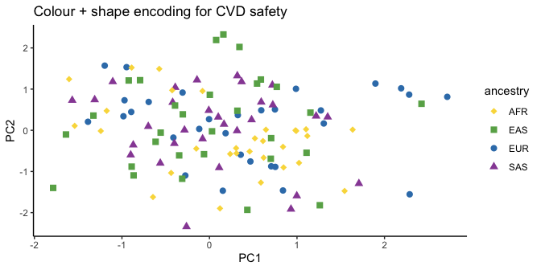

```r
set.seed(7)
groups <- c("EUR", "SAS", "EAS", "AFR")   # EUR/SAS are a deuteranopia risk pair

df_cvd <- data.frame(
  PC1      = rnorm(120),
  PC2      = rnorm(120),
  ancestry = rep(groups, each = 30)
)

# Add shape mapping so EUR and SAS are distinguishable without colour
ggplot(df_cvd, aes(PC1, PC2, color = ancestry, shape = ancestry)) +
  geom_point(size = 2.5) +
  scale_color_pgscatalog() +
  scale_shape_manual(values = c(EUR = 16, SAS = 17, EAS = 15, AFR = 18)) +
  labs(title = "Colour + shape encoding for CVD safety") +
  theme_classic()
```

## What if my labels have typos or inconsistent formatting?

Use `pgscatalog_match()` to fuzzy-match a column of messy ancestry labels to their PGS Catalog acronyms. Matching tries exact acronym, then exact full name, then edit-distance fuzzy matching — in that order.

```r
messy <- c("EUR", "eur", "european", "East Asian", "east_asian", "EAST ASIAN")
pgscatalog_match(messy, quiet = TRUE)
```

```
#> [1] "EUR" "EUR" "EUR" "EAS" "EAS" "EAS"
```

Fuzzy matches always produce a warning so you can verify them. The `max_dist` argument (default `3`) controls how many edits are allowed — lower values are stricter:

```r
# Default max_dist = 3
pgscatalog_match(c("Europeen", "sas", "Sub-Saharan African"))
```

```
#> Warning: Fuzzy matches accepted (verify these are correct):
#>   "Europeen" -> EUR
#> [1] "EUR" "SAS" "SAF"
```

```r
# Stricter: only accept 1-edit differences
pgscatalog_match(c("Europeen", "sas", "Sub-Saharan African"), max_dist = 1)
```

```
#> Warning: Fuzzy matches accepted (verify these are correct):
#>   "Europeen" -> EUR
#> [1] "EUR" "SAS" "SAF"
```

```r
# More lenient: accept up to 5 edits
pgscatalog_match(c("Afrikan", "sth_asian"), max_dist = 5)
```

```
#> Warning: Fuzzy matches accepted (verify these are correct):
#>   "Afrikan" -> AFR
#>   "sth_asian" -> SAS
#> [1] "AFR" "SAS"
```

Labels with no match within `max_dist` return `NA` with a warning:

```r
pgscatalog_match(c("EUR", "martian", "unknown_ancestry"))
```

```
#> Warning: No match found (returned NA) for:
#>   "martian"
#>   "unknown_ancestry"
#> Call pgscatalog_ancestry_info() to see valid labels.
#> [1] "EUR" NA    NA
```

The typical workflow is to call `pgscatalog_match()` once to add a clean acronym column, then pass that column to the ggplot2 scales:

```r
df_messy <- data.frame(
  sample_id     = paste0("s", 1:6),
  pgs_score     = c(0.42, -0.11, 0.87, 0.03, -0.55, 0.29),
  ancestry_raw  = c("european", "African American or Afro-Caribbean",
                    "east_asian", "South Asian", "HIS", "mid")
)

df_messy$ancestry <- pgscatalog_match(df_messy$ancestry_raw, quiet = TRUE)
df_messy[, c("ancestry_raw", "ancestry")]
```

```
#>                         ancestry_raw ancestry
#> 1                           european      EUR
#> 2 African American or Afro-Caribbean      AAM
#> 3                         east_asian      EAS
#> 4                        South Asian      SAS
#> 5                                HIS      HIS
#> 6                                mid      MID
```

## What if my data uses full ancestry names instead of acronyms?

For exact full names, `pgscatalog_match()` handles this directly. For cases where you want to inspect or customise the mapping, you can also join against `pgscatalog_ancestry_info()` manually:

```r
raw <- data.frame(
  sample_id = 1:3,
  ancestry_long = c("European", "African unspecified", "East Asian")
)

info <- pgscatalog_ancestry_info()
merged <- merge(raw, info[, c("ancestry", "acronym")],
                by.x = "ancestry_long", by.y = "ancestry")
merged
```

```
#>         ancestry_long sample_id acronym
#> 1 African unspecified         2     AFR
#> 2          East Asian         3     EAS
#> 3            European         1     EUR
```

## Citing this package

If you use `pgscatalogcolors` in a publication, please cite it as follows:

```r
citation("pgscatalogcolors")
```

```
#>
#>   Wolford B (2026). _pgscatalogcolors: Color Palettes for PGS Catalog
#>   Ancestry Groups_. R package version 0.1.0,
#>   <https://github.com/bnwolford/pgscatalogcolors>.
#>
#> A BibTeX entry for LaTeX users is
#>
#>   @Manual{,
#>     title = {{pgscatalogcolors}: Color Palettes for PGS Catalog Ancestry Groups},
#>     author = {Brooke N. Wolford},
#>     year = {2026},
#>     note = {R package version 0.1.0},
#>     url = {https://github.com/bnwolford/pgscatalogcolors},
#>   }
```

You can also retrieve the citation in BibTeX format:

```r
toBibtex(citation("pgscatalogcolors"))
@Manual{,
  title = {{pgscatalogcolors}: Color Palettes for PGS Catalog Ancestry Groups},
  author = {Brooke N. Wolford},
  year = {2026},
  note = {R package version 0.1.0},
  url = {https://github.com/bnwolford/pgscatalogcolors},
}
```